# R 문법 연습

- 문법 참고 사이트 : https://moon9342.github.io/R-lecture-R-environment

## R 개요

```r
# 변수 선언 및 사칙연산
myVar <- 100
result <- myVar + 200
print (result)

var1 = 3.141592
result = var1 * 2

cat("계산된 결과값은 : ", result)
cat("계산된 결과값은 : ", result, "\n", file="./output.txt", append=TRUE)
# rm(list = ls())
cat("\014")
```

## R Operator

### 몫, 나머지 연산자

- 몫은 `%/%`를 사용해야하고, 나머지는 `%%`를 사용해야한다.

```r
var1 <- 1000
var2 <- 3

result <- var1 / var2
print(result)
#options(digits = 5)
#result
sprintf("%0.7f", var1 / var2)
result <- var1 %/% var2
print(result)
result <- var1 %% var2
print(result)
```

### 비교연산자

```r
var1 <- 100
var2 <- 200
var1 == var2
```

```
[1] FALSE
```

```r
print(var1 == var2)
```

```
[1] FALSE
```

```r
print(var1 != var2)
```

```
[1] TRUE
```

```r
print(var1 > var2)
```

```
[1] FALSE
```

```r
print(var1 >= var2)
```

```
[1] FALSE
```

```r
print(!(var1 <= var2))
```

```
[1] FALSE
```

### 할당연산자

- `<-`, `->`

```r
var1 = 100
print(var1)
```

```
[1] 100
```

```r
var2 <- 200
print(var2)
```

```
[1] 200
```

```r
300 -> var3
print(var3)
```

```
[1] 300
```

### 논리연산자

- `&` : 기본적으로는 논리적 and 연산. 단, 조건에 있는 값이 vector이면, 모든 조건에 대해 1대1로 연산을 수행한 후 결과를 vector로 반환
- `&&` : 기본적으로는 논리적 and 연산. 단, 조건에 있는 값이 vector이면, 첫번째 조건에 대한 연산을 수행한뒤 결과를 scalar로 반환

```r
TRUE & FALSE
```

```
[1] FALSE
```

```r
TRUE && FALSE
```

```
[1] FALSE
```

```r
TRUE |  FALSE
```

```
[1] TRUE
```

```r
TRUE || FALSE
```

```
[1] TRUE
```

```r
c(TRUE, FALSE) & c(TRUE, TRUE)
```

```
[1]  TRUE FALSE
```

```r
c(TRUE, FALSE) && c(TRUE, TRUE)
```

```
[1] TRUE
```

```r
c(TRUE, FALSE) & c(TRUE, TRUE, FALSE) # Error
```

```
longer object length is not a multiple of shorter object length
```

```
[1]  TRUE FALSE FALSE
```

```r
!c(TRUE, FALSE, TRUE)
```

```
[1] FALSE  TRUE FALSE
```

### 기본적으로 제공해주는 수학함수, 값 리스트

```r
abs(-3)
```

```
[1] 3
```

```r
sqrt(16)
```

```
[1] 4
```

```r
pi
```

```
[1] 3.141593
```

```r
sign(-3)
```

```
[1] -1
```

```r
round(2.345, digits = 2)
```

```
[1] 2.35
```

```r
ceiling(2.3)
```

```
[1] 3
```

```r
floor(2.7)
```

```
[1] 2
```

```r
exp(10)
```

```
[1] 22026.47
```

```r
log(10)
```

```
[1] 2.302585
```

```r
log10(10)
```

```
[1] 1
```

```r
logb(10, base=3)
```

```
[1] 2.095903
```

```r
factorial(4)
```

```
[1] 24
```

```r
choose(4, 2)
```

```
[1] 6
```

```r
prod(1:4)
```

```
[1] 24
```

```r
sign(0.5)
```

```
[1] 1
```

```r
cos(0.5)
```

```
[1] 0.8775826
```

```r
tan(0.5)
```

```
[1] 0.5463025
```

## R Data Type

### 기본 데이터 타입

- Numeric : 숫자로 되어있으며 정수형과 실수형을 의미한다. `L` 기호를 이용하면 정수형, 그렇지 않으면 실수형으로 간주한다
- Character : 하나의 문자 혹은 문자열로 되어있으며 `""` 혹은 `''`을 사용한다.
- Logical : 참과 거짓의 논리값으로 `TRUE`(`T`) 혹은 `FALSE`(`F`)로 표현된다.
- Complex : 실수와 허수로 이루어진 복소수형태로 표현한다.

### 특수 데이터 타입

- `NULL` : 그 자체가 객체이며, 존재하지 않는 객체를 지정할 때 사용된다.
- `NA` : Not Available의 약자로 결측치(missing value)를 의미한다.
- `NaN` : Not avaiable Number의 약자로 수학적으로 연산이 불가능한 수를 의미한다
- `Inf` : Infinite의 약자로 양의 무한대를 의미한다.
- `-Inf` : 음의 무한대

### 데이터 타입 관련 함수 (`mode()`, `is()`)

- `mode()` : 문자열의 형태로 리턴
- `is.Type()` : Logical Type으로 리턴
  - 지원 메서드 리스트

[output not shown]

```
[1] "character"
```

[output not shown]

```
[1] FALSE
```

[output not shown]

```
[1] TRUE
```

```r
var1 <- c(100, TRUE, 3.1415)
var2 <- c(100, TRUE, 3.1415, "Hello")
var3 <- c(100, FALSE, 3-4i)
var4 <- c(100, FALSE, 3-4i, "안녕!!")

var1
```

```
[1] 100.0000   1.0000   3.1415
```

```r
var2
```

```
[1] "100"    "TRUE"   "3.1415" "Hello"
```

```r
var3
```

```
[1] 100+0i   0+0i   3-4i
```

```r
var4
```

```
[1] "100"    "FALSE"  "3-4i"   "안녕!!"
```

### Data Type의 우선순위

- vector는 하나의 Data Type만을 가질수 있다.
- 여러개의 타입을 하나의 vector에 넣으면 다음과 같은 순서로 Type Casting이 일어나게 된다.
- character > complex > numeric > logical

```r
var1 <- 3.1415
var2 <- 0
var3 <- "3.141592"
var4 <- "Hello"
as.character(var1)
```

```
[1] "3.1415"
```

```r
as.double(var1)
```

```
[1] 3.1415
```

```r
as.integer(var1)
```

```
[1] 3
```

```r
as.numeric(var1)
```

```
[1] 3.1415
```

```r
as.logical(var1)
```

```
[1] TRUE
```

```r
as.logical(var2)
```

```
[1] FALSE
```

```r
as.double(var3)
```

```
[1] 3.141592
```

```r
as.integer(var3)
```

```
[1] 3
```

```r
as.double(var4)
```

```
NAs introduced by coercion
```

```
[1] NA
```

### Type Casing 함수 `as()`

```r
install.packages("ggplot2")
library(ggplot2)
x <- c("a", "b", "c", "a", "b", "c")
qplot(x)
```

```r
remove.packages("ggplot2")
```

```
* Removing package(s) from project library ...
Removing package 'ggplot2' ... Done!
```

```r
.libPaths()
```

```
[1] "/home/syslab/workspace/r/learning_r/renv/library/R-3.6/x86_64-pc-linux-gnu"
[2] "/tmp/RtmpM4iSOM/renv-system-library"
```

## R 패키지와 함수

- R은 `Base system`과 `Other package`로 구별할수 있다.
  - `Base system`에는 `Base package`, `Recommended package`로 구분된다.
- `Base package` 는 설치가 필요없고 사용하기 위해서 불러오기(`library()`)를 할 필요가 없다.
- `Recommended package`는 설치는 필요없지만, 불러오기(`library()`)를 해야지 사용가능하다
- `Other package`는 설치, 불러오기 둘다 해야지만 사용 가능하다.

### package 설치하기

- `install.packages('패키지명')` : 패키지 설치하기
- `installed.packages()` : 설치된 패키지 확인하기
- `.libPaths()` : library 설치경로 확인
- `.libPaths(pathname)` : 설치경로 변경

### package 사용

- `library(packagename)`, `require(packagename)`

### package 제거

- `remove.packages(packagename)`

```r
help(mean)
args(max)
```

```
function (..., na.rm = FALSE)
NULL
```

```r
example(mean)
```

```
mean> x <- c(0:10, 50)

mean> xm <- mean(x)

mean> c(xm, mean(x, trim = 0.10))
[1] 8.75 5.50
```

```
qplot> # Use data from data.frame
qplot> qplot(mpg, wt, data = mtcars)

qplot> qplot(mpg, wt, data = mtcars, colour = cyl)

qplot> qplot(mpg, wt, data = mtcars, size = cyl)

qplot> qplot(mpg, wt, data = mtcars, facets = vs ~ am)

qplot> ## No test:
qplot> qplot(1:10, rnorm(10), colour = runif(10))

qplot> qplot(1:10, letters[1:10])

qplot> mod <- lm(mpg ~ wt, data = mtcars)

qplot> qplot(resid(mod), fitted(mod))

qplot> f <- function() {
qplot+    a <- 1:10
qplot+    b <- a ^ 2
qplot+    qplot(a, b)
qplot+ }

qplot> f()

qplot> # To set aesthetics, wrap in I()
qplot> qplot(mpg, wt, data = mtcars, colour = I("red"))

qplot> # qplot will attempt to guess what geom you want depending on the input
qplot> # both x and y supplied = scatterplot
qplot> qplot(mpg, wt, data = mtcars)

qplot> # just x supplied = histogram
qplot> qplot(mpg, data = mtcars)

qplot> # just y supplied = scatterplot, with x = seq_along(y)
qplot> qplot(y = mpg, data = mtcars)

qplot> # Use different geoms
qplot> qplot(mpg, wt, data = mtcars, geom = "path")

qplot> qplot(factor(cyl), wt, data = mtcars, geom = c("boxplot", "jitter"))

qplot> qplot(mpg, data = mtcars, geom = "dotplot")

qplot> ## End(No test)
qplot>
qplot>
qplot>
```

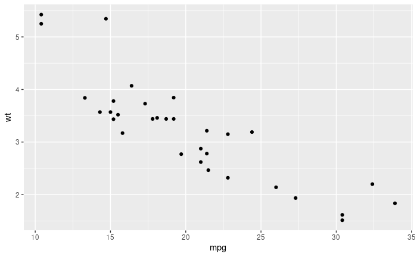

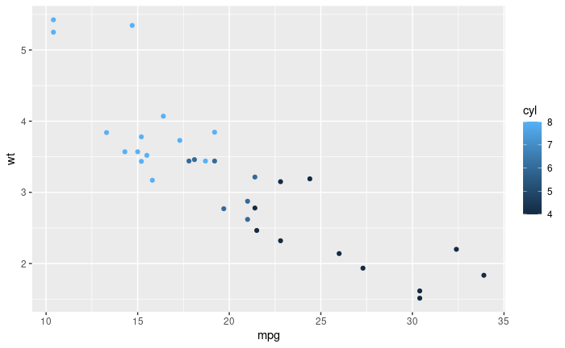

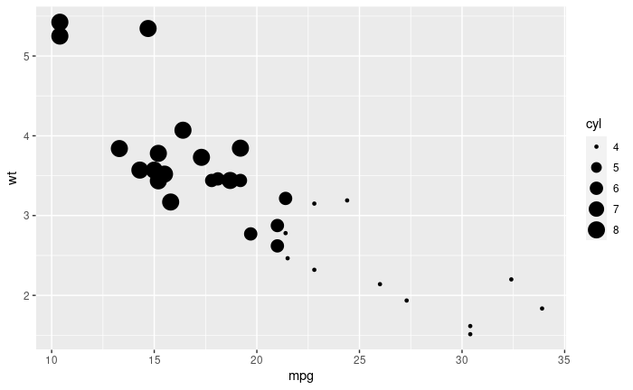

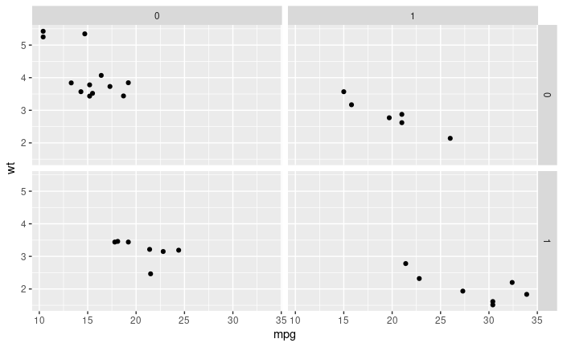

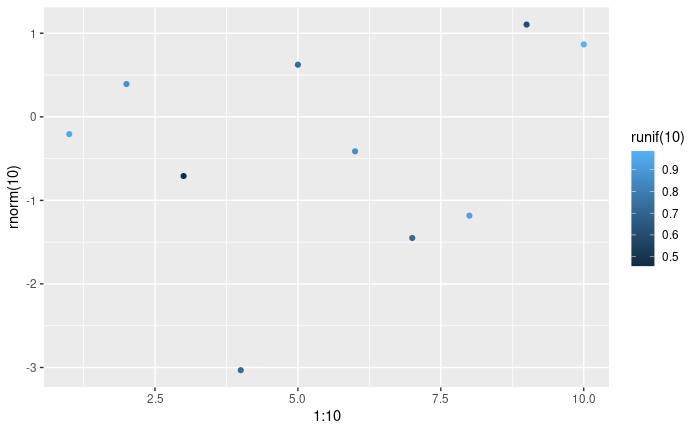

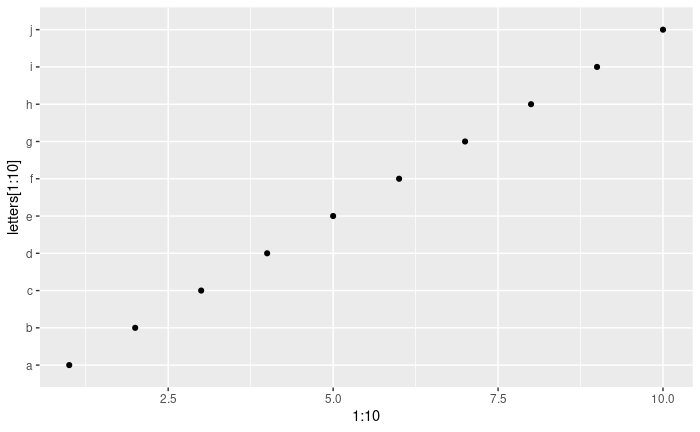

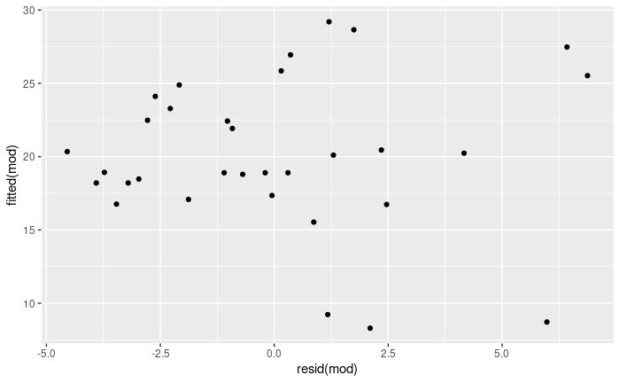

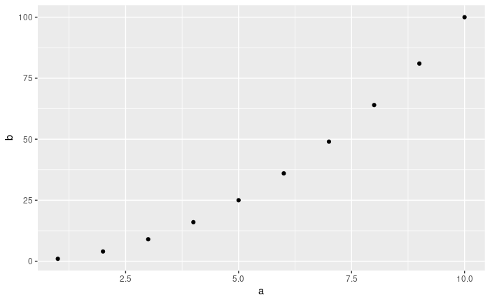

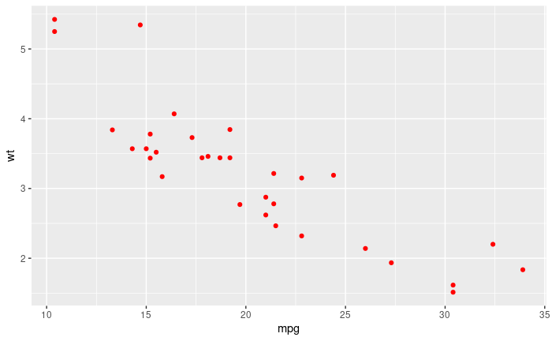

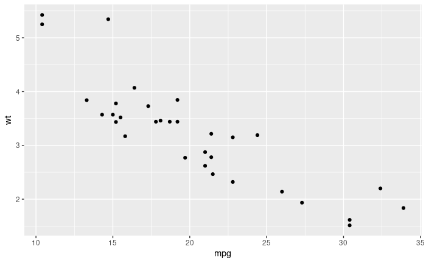

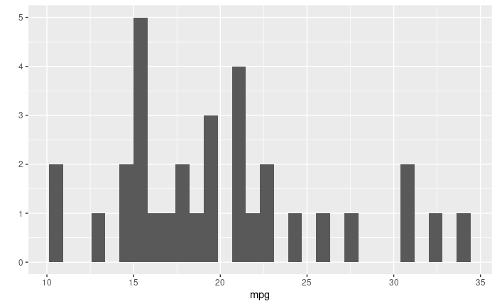

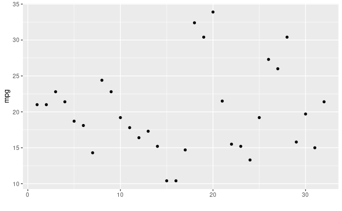

[2 more figures not shown]

```r
example(qplot)
```

### 도움 함수들

- `help()` : display function’s manual
- `args()` : display arguments of function
- `example()` : display examples of fuction

```r
 var1 = 1:5
 var1
```

```
[1] 1 2 3 4 5
```

```r
 var2 = 5:0
 var2
```

```
[1] 5 4 3 2 1 0
```

```r
 var3 = 3.3:10
 var3
```

```
[1] 3.3 4.3 5.3 6.3 7.3 8.3 9.3
```

### Workspace

- `getwd()` : return current workspace directory characters.
- `setwd(dirname)` : change working directory to `dirname`

## Chatper 5. vector

### Major Data Structure

- `Vector` : one-dimension array
- `Matrix` : two-dimension array
- `Array` : multiple-dimension array
- `List` : multiple wrapper data structure
- `Data Frame` : two-dimension table

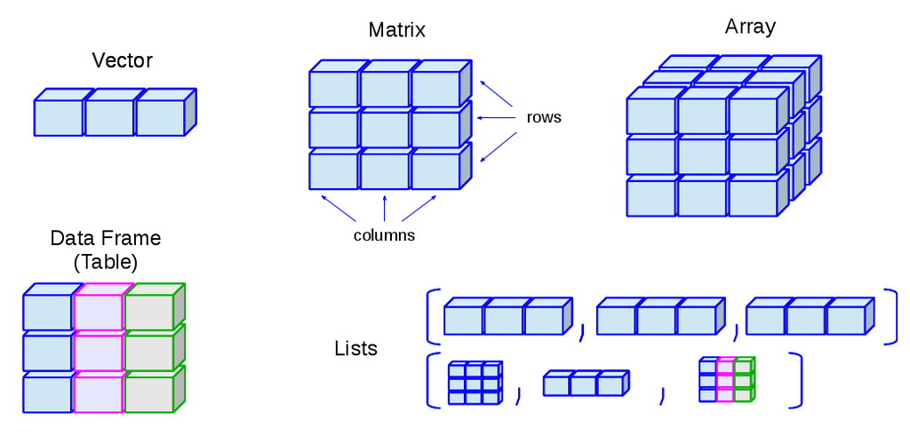

### The properties of `Vector`

- one-dimension
- Single Data Type (All elements will be cast to the same type.)
- Each elements are accessed using `variable_name[index]`. `index` is always started from 1. (1-Index)
- We call a vector, which has only one element, `scalar`. It means `scalar` is also `Vector`.

### How to create `Vector`

#### `c()`

- `c()` is the abbreviation for “combine”.

#### `:`

- `:` can be applied to only numeric. It creates elements in increments of 1.

```r
var1 = seq(from=1, to=5, by=1)
var1
```

```
[1] 1 2 3 4 5
```

#### `seq()`

- `seq()` is a generic form of `:`. It has three arguments, `from`, `to`, `by`.

```r
var1 = rep(1:3, times=3)
var1
```

```
[1] 1 2 3 1 2 3 1 2 3
```

```r
var2 = rep(1:3, each=3)
var2
```

```
[1] 1 1 1 2 2 2 3 3 3
```

#### `rep()`

```r
var1 = rep(1:3, times=3)
var1
var2 = rep(1:3, each=3)
var2
```

### How to get the length of vector : `length()`

- `length()`

```r
var1 = c(67, 90, 80, 50, 100)
var1[1]
```

```
[1] 67
```

```r
var1[length(var1)]
```

```
[1] 100
```

```r
var1[6]
```

```
[1] NA
```

```r
var1[-1]
```

```
[1]  90  80  50 100
```

```r
var1[-(2:5)]
```

```
[1] 67
```

### How to access an element of vector

- Using Index

```r
var1 = c(10, 20, 30)
names(var1)
```

```r
names(var1) = c("Kor", "Eng", "Mat")
names(var1)
```

```
[1] "Kor" "Eng" "Mat"
```

```r
var1
```

```
Kor Eng Mat
 10  20  30
```

```r
var1[1]
```

```
Kor
 10
```

```r
var1["Kor"]
```

```
Kor
 10
```

- Using name

```r
var1 = 1:3
var2 = 4:6
var1
```

```
[1] 1 2 3
```

```r
var2
```

```
[1] 4 5 6
```

```r
var1 * 2
```

```
[1] 2 4 6
```

```r
var1 + 10
```

```
[1] 11 12 13
```

```r
var2 = 1:6
var1 + var2
```

```
[1] 2 4 6 5 7 9
```

```r
var3 = 1:5
var1 + var3
```

```
longer object length is not a multiple of shorter object length
```

```
[1] 2 4 6 5 7
```

### Recycling Rule

- When we operate two vectors which of length are different, R tries to upscale the smaller.
- In this process, R has need to create new elements. So we can offer the rule of creating them.
- It called “recycling rule”.

```r
var1 = c(1, 2, 3, 4, 5)
var2 = seq(3, 7)
union(var1, var2)
```

```
[1] 1 2 3 4 5 6 7
```

```r
intersect(var1, var2)
```

```
[1] 3 4 5
```

```r
setdiff(var1, var2)
```

```
[1] 1 2
```

### set operations between Vector

- `union()`
- `intersect()`
- `setdiff()`

```r
var1 = c("HONG", "KIM", "CHOI")
var2 = c("A", "B", "C")
var3 = c("A", "B", "A", "C")
identical(var2, var3)
```

```
[1] FALSE
```

```r
setequal(var2, var3)
```

```
[1] TRUE
```

### Comparsion of vector

- `identical()`
- `setequal()`

```r
var1 = vector(mode="numeric", length=10)
var1
```

```
 [1] 0 0 0 0 0 0 0 0 0 0
```

### How to create vector without elements

```r
var1 = vector(mode="numeric", length=10)
var1
```